# A3: SPL Library Checkouts

Vincent La

### Introduction

I chose to look at all of Rick Riordan’s novels and the data related to his books as they are in the Seattle Public Library system. Rick Riordan’s Percy Jackson series was a hallmark in my childhood, and I found it fitting to do this assignment to attempt to analyze how popular those books were. In doing so, I also decided to focus not only on his best selling series, but also all of his books just to have more food for thought. His Percy Jackson series is one of the best selling series of all time, landing 14th on the list of best selling book series of all time according to a quick (wikipedia) search.

### Summary Information

The 5 values that I calculated were the average checkouts per year for each title, the highest average checkouts per year within the last 5 years, the number of books that had over 1000 checkouts, the total amount of times a book was checked out, and the amount of times a format was checked out in a year. What I found was that physical books were by far the most popular way of consuming Rick Riordan’s novels, with more checkouts than all of the other 4 combined. His most popular title is The Lightning Thief, the first book in the Percy Jackson series. There are 41 different titles, many of them repeating if they reached over 1000 checkouts in a different format, that reached over 1000 checkouts, all of which take place within the Percy Jackson universe. Interestingly enough, the Mark of Athena, the 3rd book in the second half of the series, or the 8th book overall, was the book with the highest average checkouts per year despite the Lightning Thief being the most popular book in the SPL system from Rick Riordan. An interesting trend appeared when looking at the checkout types and how they have changed over the years. Usually it was books being the most popular, however in 2021, due to the pandemic, ebooks were wildly popular and amassed 7221 checkouts, 2nd most of within this data set.

### The Dataset

The data was collected by the Seattle Public Library (SPL).

The parameters of the data includes information on every checkout made at the SPL from 2005 to today in 2023. For each checkout, the dataset includes information on the title, author, material type, audience, checkout date, and the age and patron type of the borrower. There is also a variable for the number of checkouts for each title in each year.

The data was collected by tracking all of the librarys’ checkouts.

The data was likely collected for several reasons, including tracking the usage of library materials and analyzing trends in library usage over time.

One ethical question to consider when working with this data is the privacy of the borrowers. The dataset includes information on the age and type of borrowers, which could potentially be used to identify individuals.

There are several possible limitations or problems with the data. First, the dataset only includes checkouts from the SPL, so it may not be representative of library usage in other locations. Second, the dataset includes only the number of checkouts for each title, so it does not provide information on how many people actually read or used each item. Finally, the dataset does not include information on items that were checked out but never returned, so it may underestimate the true usage of some materials. It is important to keep these limitations in mind when working with this dataset and interpreting the results.

### 15 Highest Checkouts per Year by Title and Media Type

This chart looks at the top 15 books by checkouts per year over the last 5 years. One reason I wanted to look at this was to see if digital had grown in popularity at any significance in the recent years because I thought that had I looked at the entire time length of the set then the overwhelming history that physical novels has on ebooks would make it so that the entire top 15 would consist of only physical books. As shown, there is one ebook that appears in the top 15, that being the Lightning Thief, the original book in the series. When looking at average checkouts over the entire history of the data, it appears that my thought process was incorrect as the Lightning Thief in ebook format remained as the 14th most highly checked out book per year.

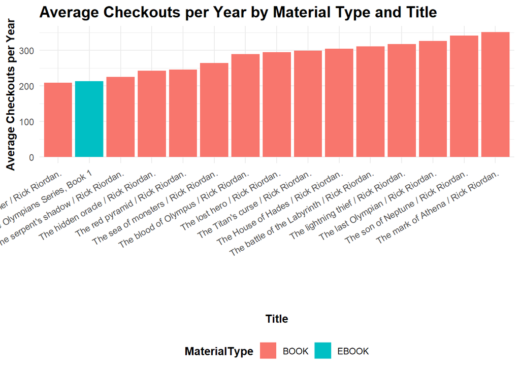

### Total Checkouts of Books by Media Type over Time

This chart looks at the total checkouts of books by media type over time. One thing this graph clearly highlights is the increasing popularity of digital formats. In the early stages of the dataset, the type of media being checked out is dominated by physical books, however as time went on we saw an increasing popularity in audiobooks and ebooks. In 2020, with the onset of the COVID-19 pandemic, we see a decrease in total checkouts, but we see that ebooks and audiobooks were the majority of checkouts for the year. That’s something that continued into 2021, and in 2022 we see the three forms of media being roughly the same. It shows how digital formats are becoming increasingly popular for a variety of reasons, though mostly due to the pandemic.

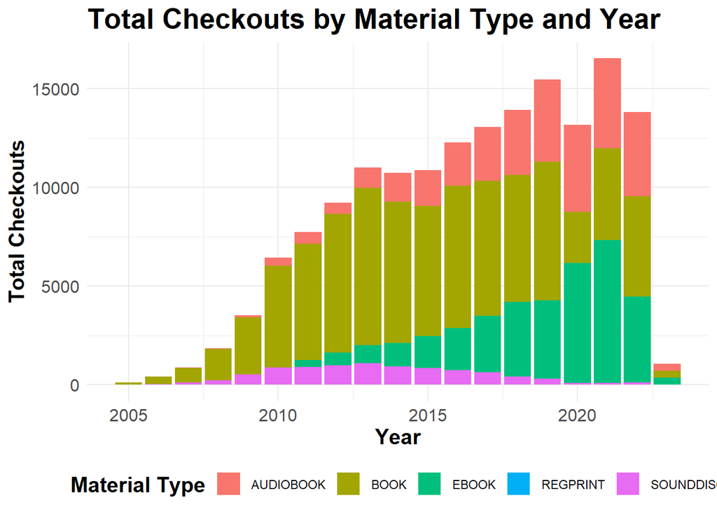

### Top 10 Books

Here are Rick Riordan’s top 10 books by checkout in the SPL system. I mostly just wanted to see if what I thought his top 10 books were what they really were according to checkouts in the SPL system. Me personally, I would agree with this list for the most part. 9 of the top 10 are from the Percy Jackson series, the first 10 books and none of the spin offs. The Lightning Thief was the first book in the series, and thus it makes sense that it is the most popular book from Riordan. One thing to note is that all of these are physical books.

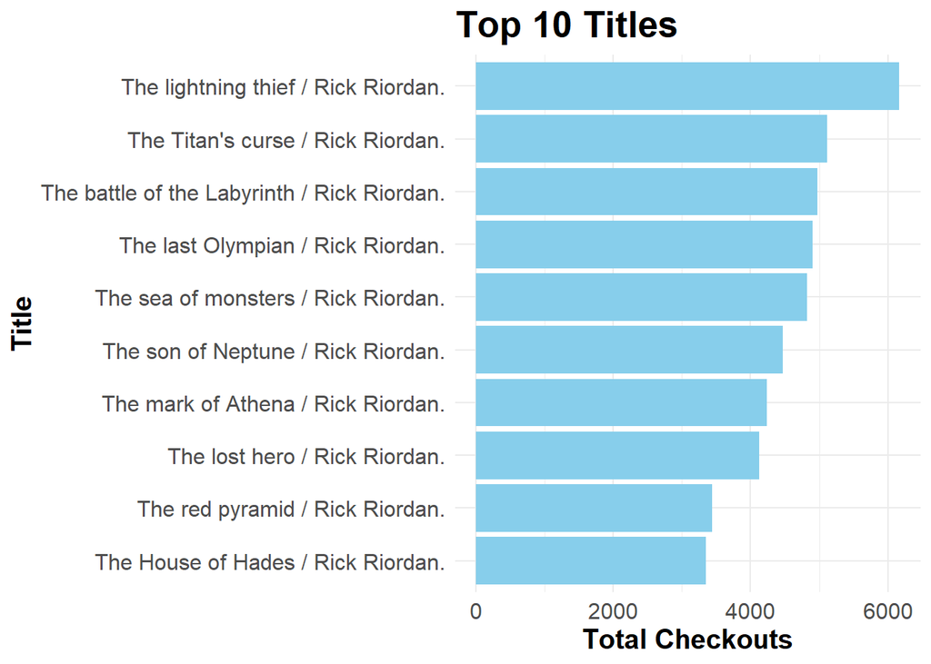